```python
# Required packages
import pandas as pd
import numpy as np

# Sklearn
from sklearn.model_selection import train_test_split, cross_val_score
from sklearn.metrics import classification_report, accuracy_score, f1_score, precision_score, recall_score
from sklearn.ensemble import StackingClassifier, RandomForestClassifier, AdaBoostClassifier
from sklearn.neural_network import MLPClassifier
from sklearn.neighbors import KNeighborsClassifier
from sklearn.svm import SVC
from sklearn.gaussian_process import GaussianProcessClassifier
from sklearn.gaussian_process.kernels import RBF
from sklearn.tree import DecisionTreeClassifier
from sklearn.naive_bayes import GaussianNB
from sklearn.discriminant_analysis import QuadraticDiscriminantAnalysis
from sklearn.preprocessing import RobustScaler
from sklearn.pipeline import make_pipeline

# Visualisation libraries

## Text
from colorama import Fore, Back, Style
from IPython.display import Image, display, Markdown, Latex, clear_output

## seaborn
import seaborn as sns
sns.set_style('whitegrid')
sns.set_context('paper', rc={'font.size':12,'axes.titlesize':14,'axes.labelsize':12})

## matplotlib
import matplotlib
import matplotlib.pyplot as plt
from matplotlib.patches import Ellipse, Polygon
import matplotlib.gridspec as gridspec
import matplotlib.colors
from pylab import rcParams
from matplotlib.font_manager import FontProperties
plt.rcParams['figure.figsize'] = 14, 8
plt.rcParams['axes.labelsize'] = 14
plt.rcParams['xtick.labelsize'] = 12
plt.rcParams['ytick.labelsize'] = 12
plt.rcParams['text.color'] = 'k'
%matplotlib inline

## plotly
from plotly.offline import init_notebook_mode, iplot
import plotly.graph_objs as go
import plotly.offline as py
from plotly.subplots import make_subplots
import plotly.express as px
# %config InlineBackend.figure_format = 'retina'

import warnings
warnings.filterwarnings("ignore")
```

**Sign Language Digits**

Sign languages are languages that can include simultaneously employing hand gestures, movement, the orientation of the fingers, arms or body, and facial expressions to convey a speaker's ideas [1]. In this article, we develop a stacking classifier model from various [scikit-learn](https://scikit-learn.org/stable/) classifiers for the Sign Language Digits dataset from [Kaggle](https://www.kaggle.com/ardamavi/sign-language-digits-dataset). The main purpose of this article is to demonstrate implementation of stacking classifiers.

# Dataset

```python
# loading the dataset
X = np.load('Data/X.npy')
y = np.load('Data/Y.npy')
```

Investigating the data, we can see that y represent numbers 0 to 9 that encoded into [dummy variables](https://pandas.pydata.org/pandas-docs/stable/reference/api/pandas.get_dummies.html).

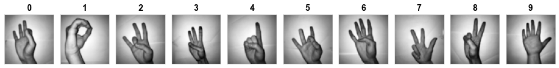

```python
_ , Values = np.nonzero(y[:,:])
Values = pd.Series(Values)

fig, ax = plt.subplots(nrows=1, ncols=10, figsize=(13, 8), subplot_kw={'xticks': [], 'yticks': []})
font = FontProperties()
font.set_weight('bold')

Ind = [Values[Values == i].index.min() for i in Values.unique()]
for i in range(len(ax)):
    ax[i].imshow(X[Ind[i],:,:], cmap = 'gray')
    ax[i].set_title('%i' % np.nonzero(y[Ind[i],:]), fontproperties=font, fontsize = 14)

fig.tight_layout()
```

# Train and Test sets

Let's split the data into random train and test subsets using [sklearn.model_selection.train_test_split](https://scikit-learn.org/stable/modules/generated/sklearn.model_selection.train_test_split.html).

```python
y = Values.copy()
del Values

X_train, X_test, y_train, y_test = train_test_split(X, y, test_size = 0.2, random_state = 42)
pd.DataFrame(data={'Set':['X_train','X_test','y_train','y_test'],
                   'Shape':[X_train.shape, X_test.shape, y_train.shape, y_test.shape]}).set_index('Set').T
```

| Set | X_train | X_test | y_train | y_test |
| --- | --- | --- | --- | --- |
| Shape | (1649, 64, 64) | (413, 64, 64) | (1649,) | (413,) |

```python
def Flat(Inp): return Inp.reshape(Inp.shape[0],Inp.shape[1]*Inp.shape[2])

X_train, X_test = Flat(X_train), Flat(X_test)
pd.DataFrame(data={'Set':['X_train','X_test','y_train','y_test'],
                   'Shape':[X_train.shape, X_test.shape, y_train.shape, y_test.shape]}).set_index('Set').T
```

| Set | X_train | X_test | y_train | y_test |
| --- | --- | --- | --- | --- |
| Shape | (1649, 4096) | (413, 4096) | (1649,) | (413,) |

## Classifiers

```python
classifiers = [
    ('Nearest Neighbors', KNeighborsClassifier(n_neighbors = len(np.unique(y)), weights = 'uniform')),
    ('Linear SVM', SVC(kernel="linear", C=0.025, gamma = 'auto', probability = True)),
    ('RBF SVM', SVC(kernel="rbf", C=1, gamma = 'auto', probability = True)),
    ('Gaussian Process', GaussianProcessClassifier(kernel = 1.0 * RBF(1.0))),
    ('Decision Tree', DecisionTreeClassifier(max_features = None, random_state = 0)),
    ('Random Forest', RandomForestClassifier(n_estimators = 100, oob_score = True)),
#     ('Neural Network', MLPClassifier(hidden_layer_sizes=(50,), max_iter=10, alpha=1e-4,
#                                      solver='lbfgs', random_state=0, learning_rate_init=.1)),
    ('AdaBoost', AdaBoostClassifier(n_estimators = 100, algorithm =  'SAMME.R', random_state = 0)),
    ('Naive Bayes', GaussianNB()),
    ('QDA', QuadraticDiscriminantAnalysis())]

Performance = []
classifiers_names = []
for (name, clf) in classifiers:
    clf.fit(X_train, y_train)
    y_pred = clf.predict(X_test)
    classifiers_names.append(name)
    Performance.append([clf.score(X_test, y_test),
                        f1_score(y_test.values, y_pred, average= 'weighted'),
                        precision_score(y_test.values, y_pred, average= 'weighted'),
                        recall_score(y_test.values, y_pred, average= 'weighted')])
del clf, name, y_pred
Performance = pd.DataFrame(Performance,
                           columns=['Score','F1 Score', 'Precision Score', 'Recall Score'], index = classifiers_names)

def highlight_max(s):
    is_max = s == s.max()
    return ['background-color: SpringGreen' if v else '' for v in is_max]

display(Performance.style.apply(highlight_max, subset=['Score']))
```

|  | Score | F1 Score | Precision Score | Recall Score |
| --- | --- | --- | --- | --- |
| Nearest Neighbors | 0.721550 | 0.721378 | 0.740337 | 0.721550 |
| Linear SVM | 0.823245 | 0.823315 | 0.829169 | 0.823245 |
| RBF SVM | 0.445521 | 0.382973 | 0.397911 | 0.445521 |
| Gaussian Process | 0.322034 | 0.339521 | 0.634323 | 0.322034 |
| Decision Tree | 0.564165 | 0.564817 | 0.570905 | 0.564165 |
| Random Forest | 0.796610 | 0.797555 | 0.800645 | 0.796610 |
| AdaBoost | 0.375303 | 0.355666 | 0.349734 | 0.375303 |
| Naive Bayes | 0.631961 | 0.629738 | 0.639181 | 0.631961 |
| QDA | 0.215496 | 0.212776 | 0.216864 | 0.215496 |

## Stackeding Classifier

```python
Temp = Performance.loc[Performance.Score>=.6].sort_values(by=Performance.columns.tolist(), ascending=False).index.tolist()
New_list = []
for (name, clf) in classifiers:
    if name in Temp:
        New_list.append((name, clf))
    if name in Temp[0]:
        Best = (name, clf)

stacked = StackingClassifier(estimators = New_list, final_estimator=Best[1])
stacked.fit(X_train, y_train)
del Temp, name, clf

Temp = [stacked.score(X_test, y_test),
        f1_score(y_test.values, stacked.predict(X_test), average= 'weighted'),
        precision_score(y_test.values, stacked.predict(X_test), average= 'weighted'),
        recall_score(y_test.values, stacked.predict(X_test), average= 'weighted')]
Temp = pd.DataFrame(Temp, index = Performance.columns, columns = ['Stacked Classifier']).T

Temp0 = [name for (name,_) in New_list]
Temp0.append(Temp.index.tolist()[0])

Performance = Performance.loc[Performance.index.isin(Temp0)].append(Temp)\
            .sort_values(by=Performance.columns.tolist(), ascending=False)

Performance.style.background_gradient(cmap=sns.light_palette("green", as_cmap=True), subset=['Score'] ).set_precision(4)
```

|  | Score | F1 Score | Precision Score | Recall Score |
| --- | --- | --- | --- | --- |
| Stacked Classifier | 0.8281 | 0.8299 | 0.8345 | 0.8281 |
| Linear SVM | 0.8232 | 0.8233 | 0.8292 | 0.8232 |
| Random Forest | 0.7966 | 0.7976 | 0.8006 | 0.7966 |
| Nearest Neighbors | 0.7215 | 0.7214 | 0.7403 | 0.7215 |
| Naive Bayes | 0.6320 | 0.6297 | 0.6392 | 0.6320 |

The stacking classifier has improved the accuracy of our classifications.

# References

1. [Sign language Wikipedia Page](https://en.wikipedia.org/wiki/Sign_language)
2. [Sign Language Digits Dataset](https://github.com/ardamavi/Sign-Language-Digits-Dataset)